What are the disc golf discs that Reddit recommends the most for beginners? And where the heck are all the [Kastaplast](https://amzn.to/3hFsoVy)?!

The first post about [Reddit’s most commonly recommended discs](https://discgolfdata.com/2020/12/31/The-most-recommended-discs-on-Reddit.html) was well received with over 1200 visitors to the site and lots of positive discussion on the [thread](https://www.reddit.com/r/discgolf/comments/kp1loy/i_made_a_thing_the_most_recommended_discs_on/). However, there were a few points I thought would be fun to follow-up on.

A lot of people thought the first pass generated a pretty good list of beginner discs or a “starter bag”. To improve on this, I largely followed the same steps detailed for the full post ([code available here](https://discgolfdata.com/pages/code_walkthroughs/redditdiscs.html)) but with the added strings of “beginner” and “new player” in the URLs that `redditextractoR` compiled. I also manually excluded some obvious outliers like [Innova’s Destroyer](https://amzn.to/2JEXUq8) which probably shows up due to it specifically being brought up as a *bad* disc for beginners. Hopefully in the future I can learn how to automate this in some sort of sentiment analysis.

There was also some wonder about where some of the more obviously popular discs were like [Kastaplast’s](https://amzn.to/3hFsoVy) Berg, [Axiom Envy](https://amzn.to/2X3Ekai), [Discmania’s](https://amzn.to/2X8hQEY) hyped discs, and others. In the original analysis I suspect those discs don’t make the cut because they aren’t usually “recommended” or “suggested” - but instead show up in other threads. To follow up on this hunch, I thought we could look at the results of over 300 recent posts about “Mail Calls” to see if these missing popular discs can be found.

First, the top 20 most recommended “beginner” discs…

## Reddit’s Top 20 most recommended beginner discs

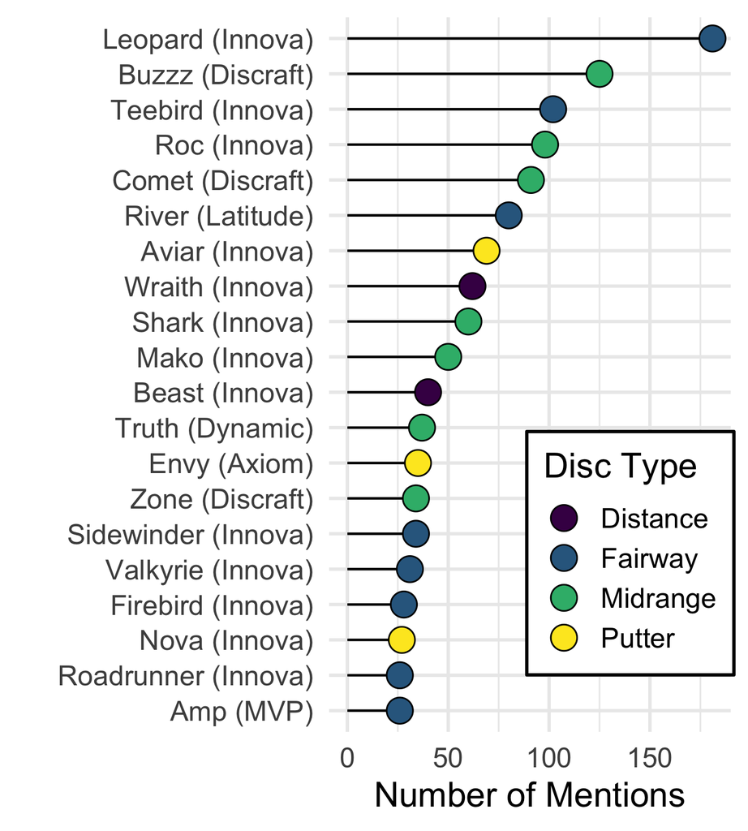

*Discs ranked by their number of mentions in recent r/discgolf threads about the “best beginner disc” or beginner disc “suggestions” or “recommendations”.*

I feel pretty good about this result - although it’s not hugely different from the [Top 20 recommended overall](https://discgolfdata.com/2020/12/31/The-most-recommended-discs-on-Reddit.html) there are some key differences.

The [Leopard](https://amzn.to/3n4YIT4) is by far the most recommended beginner disc and rises from 5th overall to the #1 beginner spot. The [Zone](https://amzn.to/2X6QhvQ) and [Firebird](https://amzn.to/3hCT0Xg), two very overstable discs, drop way down from their overall ranking though they still make the top 20. Overall this suggests to me that the process worked and we yielded a little bit better of a beginner list.

Maybe grab the [Innova starter set](https://amzn.to/353V9q1) and put the [Destroyer](https://amzn.to/2JEXUq8) aside for a while!

Next up, Discraft’s [Buzzz](https://amzn.to/3pJ8vQ6) is also another excellent suggestion. I throw a Big Z [Buzzz](https://amzn.to/3pJ8vQ6) and while it’s a great beginner disc, it’s also one you can mature into for really dead straight shots with a lot of power.

Here’s some more details about these discs and the top 50 beginner discs total.

|  | Type | Speed | Glide | Turn | Fade |
| --- | --- | --- | --- | --- | --- |
| Innova Leopard | Fairway | 6 | 5 | -2 | 1 |
| Discraft Buzzz | Midrange | 5 | 4 | -1 | 1 |
| Innova Teebird | Fairway | 7 | 5 | 0 | 2 |
| Innova Roc | Midrange | 4 | 4 | 0 | 3 |
| Discraft Comet | Midrange | 4 | 5 | -2 | 1 |
| Latitude 64 River | Fairway | 7 | 7 | -1 | 1 |
| Innova Aviar | Putter | 2 | 3 | 0 | 1 |
| Innova Wraith | Distance | 11 | 5 | -1 | 3 |
| Innova Shark | Midrange | 4 | 4 | 0 | 2 |
| Innova Mako | Midrange | 4 | 5 | 0 | 0 |

[output cut: 40 more lines]

These discs are great for building a basic bag (or rounding out anyone’s, really) but what about that beloved [Kastaplast](https://amzn.to/3hFsoVy)? Readers insisted it should be there!!

## Mail Call! The discs Reddit most likes to show off

For this exercise I re-ran `redditextractoR` with the search term “Mail Call” and pulled the results for over 300 posts (nearly 6,000 comments) from the past several months.

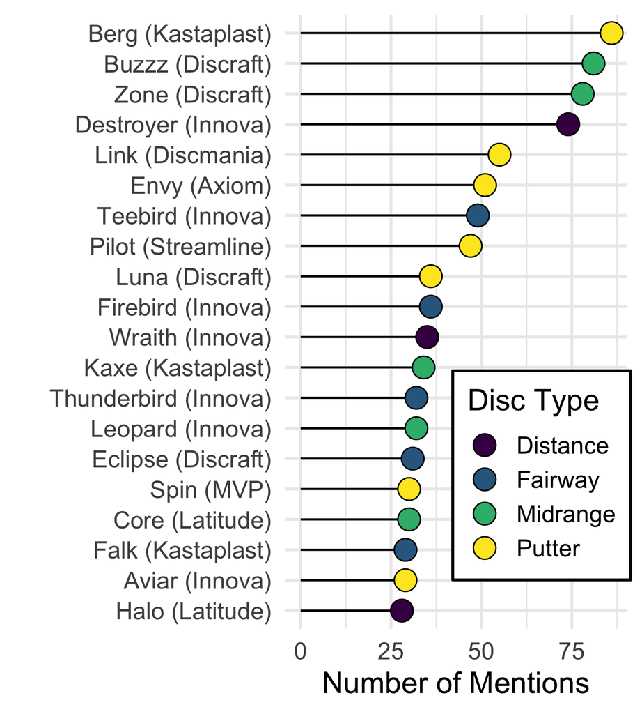

*Discs ranked by their number of mentions in over 300 recent r/discgolf “mail call” threads.*

Blam! Folks expressed some (friendly) skepticism before when [Kastaplast](https://amzn.to/3hFsoVy) failed to crack the Top 20 - surely that can’t be true as it seems to be all that gets discussed! But with a little tweak from looking at “recommended” threads to “mail call” threads we see [Kastaplast](https://amzn.to/3hFsoVy) blast onto the scene and occupying the #1 spot with the Berg and claiming 3 of the top 20 spots.

This look also pulls up some other popular discs absent or ranked low on the previous analysis. Notably [Discmania](https://amzn.to/2X8hQEY) makes an appearence with the [Link](https://amzn.to/38UHYJ3), [Axiom’s Envy](https://amzn.to/2X3Ekai) rocket up the list, and the [Discraft Luna](https://infinitediscs.com/Discraft-Luna) jumps up into the top 10.

A few weirdos get retained as artifacts of the extraction process. I don’t think I ever even heard of the [Discraft Eclipse](https://infinitediscs.com/Discraft-Eclipse) before and the Latitude Halo is likely instead folks showing off their [Halo Destroyers](https://amzn.to/2X3TE6I). However, overall the list *feels* pretty much right. Seems like everyone loves to bag a [Aviar](https://amzn.to/3hQvVAJ) but not many care to show it off!

Here’s the top 50 if you care to explore a little more!

|  | Type | Speed | Glide | Turn | Fade |
| --- | --- | --- | --- | --- | --- |
| Kastaplast Berg | Putter | 1 | 1 | 0 | 2 |
| Discraft Buzzz | Midrange | 5 | 4 | -1 | 1 |
| Discraft Zone | Midrange | 4 | 3 | 0 | 3 |
| Discmania Link | Putter | 2 | 3 | 0 | 1 |
| Axiom Discs Envy | Putter | 3 | 3 | 0 | 2 |
| Innova Teebird | Fairway | 7 | 5 | 0 | 2 |
| Streamline Discs Pilot | Putter | 2 | 5 | -1 | 1 |
| Innova Firebird | Fairway | 9 | 3 | 0 | 4 |
| Discraft Luna | Putter | 3 | 4 | 0 | 2 |
| Innova Wraith | Distance | 11 | 5 | -1 | 3 |

[output cut: 40 more lines]

Thanks for reading! Now stop *thinking* about throwing discs and *get out there*!